# What To Consider when Investing in P2P Prosper Loan

## by Abdulmalek Alsaati

## Investigation Overview

P2P lending platform industry is thriving in recent years. Thousands of investors are making profit through these platforms, in this Analysis we will invistigate what should to consider when investing in this Platform.

## Dataset Overview

Here I will explore Prosper data set and try to find out some patterns behind borrowers properties, the dataset which we will analysis contains 81 variables and 113,979 observation for each loan list data during 2005 to 2014.

## Estimated Return Figure.

looking at the estimated reutrn for P2P investment, most of the loans have an estimated return between 4% and 20%, and there is peak point at 8% and 12%, if we zoom estimated Loss, we can see there is some distribution between -17% to 1%, top loss frequency is -2.5% and -5%.

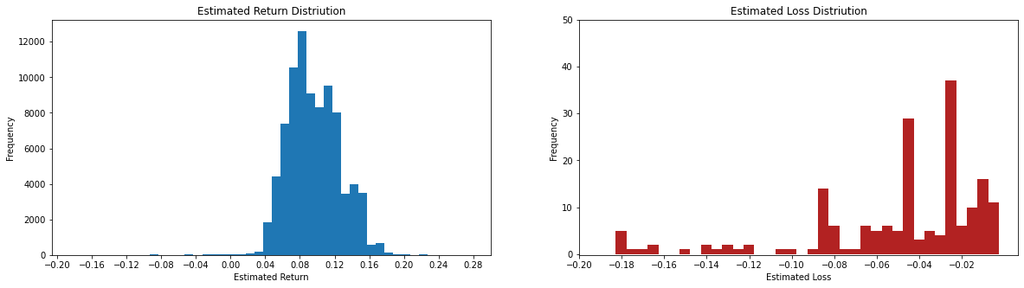

## Employenment Staus.

Employement status should be considerd, as the most completed Borrowing status is for Employeed and Full-time borrowers, we can spot more than 17k completed status for Full-time and 12K for Employeed status.

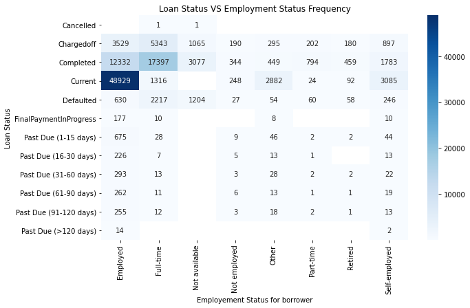

## Prosper Rating.

This chart suggests that investing in borrowers with proser Class D and E will produce the highest returns. but this need more exploration as it might combined with higher risk.

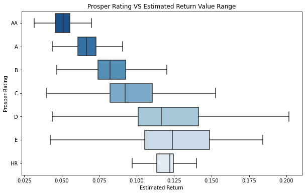

## Safe Estimated Return

Finally, from this chart, we can clearly see that each Prosper rating is group with specific return, there is lot of vaiabilities for High risk borrower and there is chance for mony loss. Also this chart suggest a safe range borrower classes which are (AA, A and B), the classes (C and D) are linked to higher return but also linked to small chance of mony losss. In addition this chart suggest borrwing limit for each classes, which to invist more in safe classes, but less in risky classes.

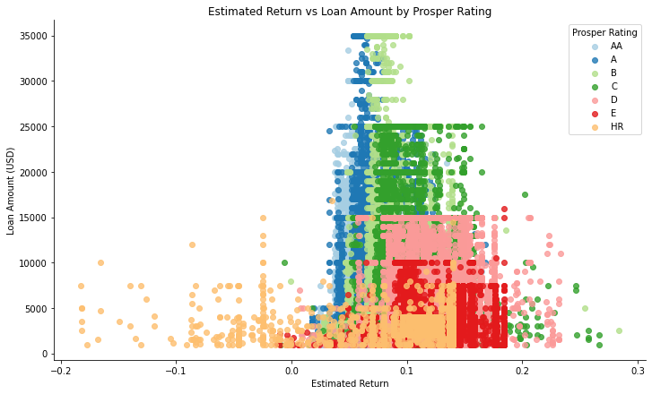